# O que é um Jupyter Notebook?

Neste caso, o notebook é um formato de documento que contém tanto códigos quanto elementos de texto, figuras, links, vídeos, equações, etc. Como podemos misturar texto e código em um mesmo lugar, esses documentos são lugares ideais para gerar e descrever análises onde tanto a formulação da ideia, a visualização do resultado e a descrição do resultado pode ser feita num mesmo lugar

## Células

Isso é uma célula de texto. Células de texto aceitam marcação conhecida como Markdown.

Em uma célula de código nós podemos usar o Python como usamos em um script qualquer:

```python
# isso é uma célula de código

import matplotlib.pyplot as plt
%matplotlib inline
```

Cada célula é um ambiente isolado que pode ser rodado separadamente. Você pode rodar cada célula individualmente e na sequência que desejar, mas as variáveis que ela usa precisam estar referenciadas antes do seu uso.

```python
for i in range(0, 10):
    print(i)
```

```
0
1
2
3
4
5
6
7
8
9
```

## Fórmulas matemáticas

Também é possível usar fórmulas junto com o texto. Isso é muito útil quando se tem uma explicação matemática necessária para entender o código. A escrita é feita da mesma forma que no LaTeX:

$$c = \sqrt{a^2 + b^2}$$

## Visualização

Na área de imports colocamos um `%matplotlib inline`, certo? Essa é uma das "mágicas" disponíveis no Jupyter que permite que os gráficos do `matplotlib` sejam apresentados dentro do próprio notebook, como podemos ver abaixo:

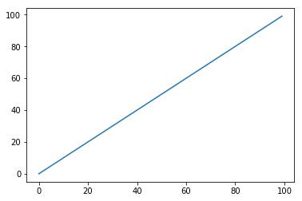

```python
plt.plot(range(0,100))
```

## Vídeos

Também podemos inserir vídeos do youtube como parte da sequência lógica da explicação:

```python
from IPython.display import YouTubeVideo
YouTubeVideo('qrSt5fTFxPk')
```

[video not shown]